```r
options(OutDec = ".")  # Asegurar punto decimal en este chunk

# Establecer semilla aleatoria
set.seed(sample(1:10000, 1))

# Aleatorizar el contexto del problema
contextos <- c(
  "un esquiador que se desliza por una montaña de nieve",
  "un trineo que desciende por una colina nevada",
  "un snowboarder que baja por una pendiente",
  "un paracaidista durante su caída",
  "un objeto en caída libre",
  "un tobogán acuático",
  "una pelota que cae desde una altura",
  "un montañista en descenso",
  "un dron que desciende en línea recta",
  "una persona en un descenso alpino"
)
contexto <- sample(contextos, 1)

# Aleatorizar la altura inicial (en metros)
altura_inicial <- sample(c(12, 14, 15, 16, 18, 20), 1)

# Aleatorizar la altura final (en metros)
altura_final <- sample(c(0, 1, 2), 1)

# Aleatorizar el tiempo total (en segundos)
tiempo_total <- sample(c(20, 22, 24, 26, 28, 30), 1)

# Aleatorizar el tiempo para la pregunta (entre 2 y tiempo_total)
tiempo_pregunta <- sample(seq(10, 18, by = 2), 1)

# Calcular la pendiente y la constante de la recta
pendiente <- (altura_final - altura_inicial) / tiempo_total
constante <- altura_inicial

# Calcular la altura en el tiempo de la pregunta
altura_tiempo_pregunta <- round(pendiente * tiempo_pregunta + constante)

# Generar opciones de respuesta
opciones <- c(
  altura_tiempo_pregunta,  # Opción correcta
  sample(c(4, altura_tiempo_pregunta - 4), 1),  # Distractor 1
  sample(c(8, altura_tiempo_pregunta + 4), 1),  # Distractor 2
  altura_inicial  # Distractor 3 (altura inicial)
)

# Asegurar que todas las opciones sean diferentes
while(length(unique(opciones)) < 4) {
  opciones[2] <- sample(seq(2, altura_inicial-2, by = 2), 1)
  opciones[3] <- sample(seq(2, altura_inicial-2, by = 2), 1)
}

# Mezclar opciones
indice_correcto <- which(opciones == altura_tiempo_pregunta)
opciones_mezcladas <- sample(opciones)
indice_correcto_mezclado <- which(opciones_mezcladas == altura_tiempo_pregunta)

# Vector de solución para r-exams
solucion <- rep(0, 4)
solucion[indice_correcto_mezclado] <- 1

# Aleatorizar colores para la gráfica
colores_linea <- c("blue", "red", "darkgreen", "purple", "brown", "black")
color_linea <- sample(colores_linea, 1)
```

```r
options(OutDec = ".")  # Asegurar punto decimal en este chunk

# Definir el código Python para la gráfica
codigo_python_grafica <- sprintf("
import matplotlib.pyplot as plt
import numpy as np
import matplotlib
matplotlib.rcParams['font.size'] = 11

# Datos para la gráfica
altura_inicial = %d
altura_final = %d
tiempo_total = %d
tiempo_pregunta = %d
pendiente = %f
constante = %d

# Generar puntos para la línea
tiempos = np.linspace(0, tiempo_total, 100)
alturas = pendiente * tiempos + constante

# Crear la figura
plt.figure(figsize=(6, 4))

# Dibujar la línea principal
plt.plot(tiempos, alturas, color='%s', linewidth=2)

# Marcar el punto en el tiempo de la pregunta con una línea vertical
#plt.axvline(x=tiempo_pregunta, color='black', linestyle='-', linewidth=0.8)
#plt.plot([tiempo_pregunta], [pendiente * tiempo_pregunta + constante], 'o', #color='black', markersize=5)

# Configurar ejes y etiquetas
plt.axis([0, tiempo_total, 0, altura_inicial + 2])
plt.xlabel('Tiempo (segundos)')
plt.ylabel('Altura (metros)')
plt.grid(True, linestyle='--', alpha=0.7)

# Crear marcas en los ejes
paso_tiempo = 2
paso_altura = 2
plt.xticks(np.arange(0, tiempo_total + 1, paso_tiempo))
plt.yticks(np.arange(0, altura_inicial + 3, paso_altura))

# Guardar la gráfica
plt.tight_layout()
plt.savefig('grafica_altura_tiempo.png', dpi=150)
plt.close()
",
altura_inicial, altura_final, tiempo_total, tiempo_pregunta, pendiente, constante, color_linea)

# Ejecutar el código Python para generar la gráfica
py_run_string(codigo_python_grafica)
```

# Question

La gráfica muestra la relación entre la altura y el tiempo de un tobogán acuático.

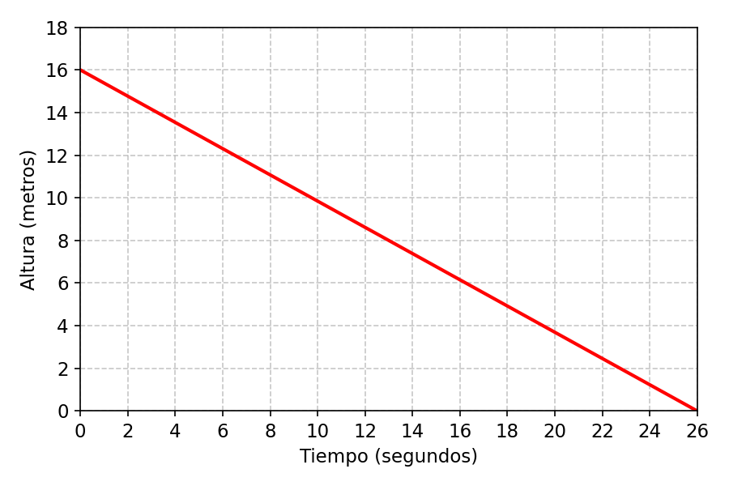

De acuerdo con la gráfica, ¿cuál es la altura a los 16 segundos?

## Answerlist

- 6 metros.
- 16 metros.
- 10 metros.
- 4 metros.

# Solution

Para resolver este problema, debemos determinar la altura correspondiente a un tiempo de 16 segundos en la gráfica dada.

La gráfica muestra una relación lineal entre la altura y el tiempo, con una pendiente negativa. Esto significa que la altura disminuye a medida que aumenta el tiempo.

La ecuación de esta recta es: $y = mx + b$

Donde:

- $y$ es la altura (en metros)
- $x$ es el tiempo (en segundos)
- $m$ es la pendiente de la recta: $m = \frac{0 - 16}{26} = -0.6153846$
- $b$ es la altura inicial: $b = 16$ metros

Sustituyendo el tiempo de 16 segundos en la ecuación:

$y = (-0.6153846) \cdot (16) + (16)$ $y = -9.8461538 + 16$ $y = 6$ metros

Por lo tanto, a los 16 segundos, la altura es de 6 metros.

## Answerlist

- Verdadero
- Falso
- Falso
- Falso

# Meta-information

exname: relacion_altura_tiempo extype: schoice exsolution: 1000 exshuffle: FALSE exsection: Funciones lineales